# OzElectShapefiles

Heike Hofmann

April 22, 2016

The Australian Electorate Commission publishes the boundaries of the electorates on their website at http://www.aec.gov.au/Electorates/gis/gis_datadownload.htm.

Once the files (preferrably the national files) are downloaded, unzip the file (it will build a folder with a set of files). We want to read the shapes contained in the `shp` file into R.

```r
library(maptools)

# shapeFile contains the path to the shp file:
shapeFile <- "national-esri-16122011/COM20111216_ELB_region.shp"
sF <- readShapeSpatial(shapeFile)
class(sF)
```

```
## [1] "SpatialPolygonsDataFrame"
## attr(,"package")
## [1] "sp"
```

`sF` is a spatial data frame containing all of the polygons. We use the `rmapshaper` package available from ateucher’s github page to thin the polygons while preserving the geography:

```r
require(rmapshaper)
```

If the library is not available, install it from gitguh using `devtools::install_github("ateucher/rmapshaper")`.

```r
sFsmall <- ms_simplify(sF, keep=0.05) # use instead of thinnedSpatialPoly
```

`keep` indicates the percentage of points we want to keep in the polygons. 5% makes the electorate boundary still quite recognizable, but reduce the overall size of the map considerably, making it faster to plot.

We can use base graphics to plot this map:

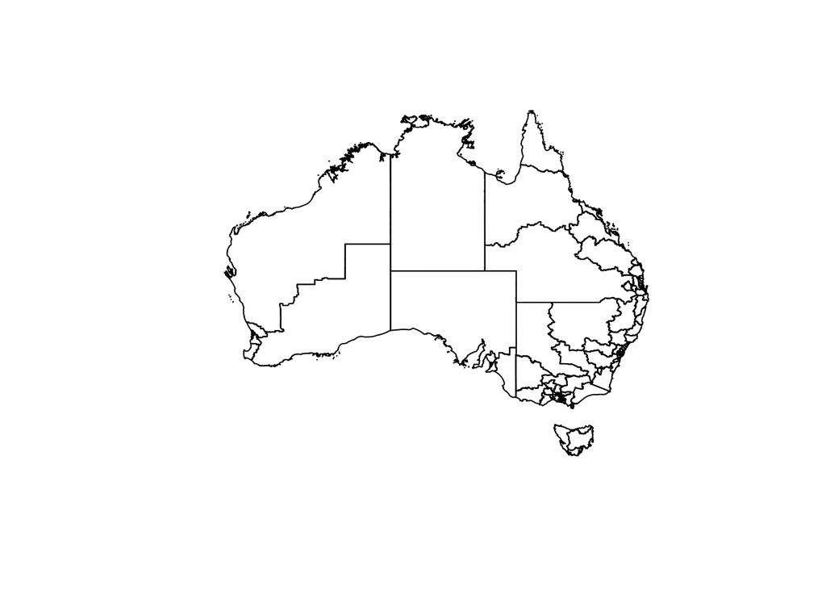

```r
plot(sFsmall)
```

### Extracting the electorate information

A spatial polygons data frame consists of both a data set with information on each of the entities (in this case, electorates), and a set of polygons for each electorate (sometimes multiple polygons are needed, e.g. if the electorate has islands). We want to extract both of these parts.

```r
nat_data <- sF@data
head(nat_data)
```

```
##   ELECT_DIV STATE NUMCCDS ACTUAL PROJECTED POPULATION OVER_18   AREA_SQKM
## 0  Lingiari    NT     335      0         0          0       0 1352034.050
## 1   Solomon    NT     180      0         0          0       0     336.686
## 2  Canberra   ACT     283      0         0          0       0    1920.480
## 3    Fraser   ACT     270      0         0          0       0     505.246
## 4     Brand    WA     243      0         0          0       0     410.530
## 5   Canning    WA     268      0         0          0       0    6178.040
##   SORTNAME
## 0 Lingiari
## 1  Solomon
## 2 Canberra
## 3   Fraser
## 4    Brand
## 5  Canning
```

The row names of the data file are identifiers corresponding to the polygons - we want to make them a separate variable:

```r
nat_data$id <- row.names(nat_data)
```

In the currently published version of the 2013 electorate boundaries, the `data` data frame has variable `ELECT_DIV` of the electorates’ names, and variable `STATE`, which is an abbreviation of the state name. It might be convenient to merge this information (or at least the state abbreviation) into the polygons (see below). We are almost ready to export this data into a file, but we still want include geographic centers in the data (see also below).

### Extracting the polygon information

The `fortify` function in the `ggplot2` package extracts the polygons into a data frame.

```r
nat_map <- ggplot2::fortify(sFsmall)
head(nat_map)
```

```
##       long       lat order  hole piece id group
## 1 137.9982 -23.52089     1 FALSE     1  0   0.1
## 2 137.9984 -23.58319     2 FALSE     1  0   0.1
## 3 137.9984 -23.66652     3 FALSE     1  0   0.1
## 4 137.9985 -23.74985     4 FALSE     1  0   0.1
## 5 137.9985 -23.83318     5 FALSE     1  0   0.1
## 6 137.9985 -23.91651     6 FALSE     1  0   0.1
```

We need to make sure that `group` and `piece` are kept as factor variables - if they are allowed to be converted to numeric values, it messes things up, because as factor levels `9` and `9.0` are distinct, whereas they are not when interpreted as numbers …

```r
nat_map$group <- paste("g",nat_map$group,sep=".")
nat_map$piece <- paste("p",nat_map$piece,sep=".")
```

The map data is ready to be exported to a file:

```r
write.csv(nat_map, "National-map-2013.csv", row.names=FALSE)
```

### Getting centroids

Getting centroids or any other information from a polygon is fairly simple, once you have worked your way through the polygon structure. First, we are going to just focus on the polygons themselves:

```r
polys <- as(sF, "SpatialPolygons")
class(polys) # should be SpatialPolygons
```

```
## [1] "SpatialPolygons"
## attr(,"package")
## [1] "sp"
```

```r
length(polys) # should be 150
```

```
## [1] 150
```

Because SpatialPolygons are an S4 object, they have so called `slots`, and in this case the slots are:

```r
slotNames(polys)
```

```
## [1] "polygons"    "plotOrder"   "bbox"        "proj4string"
```

We are interested further into the polygon aspect of this object:

```r
Polygon(polys[1])
```

```
## An object of class "Polygon"
## Slot "labpt":
## [1] 133.37057 -19.48052
##
## Slot "area":
## [1] 0
##
## Slot "hole":
## [1] FALSE
##
## Slot "ringDir":
## [1] 1
##
## Slot "coords":
##       [,1]      [,2]
## 0 133.3706 -19.48052
```

From this, we want to extract the `labpt` component, because those are the centroids we are interested in. We will wrap this into a little function called `centroid` to help us with that:

```r
library(dplyr)
```

```r
centroid <- function(i, polys) {
  ctr <- Polygon(polys[i])@labpt
  data.frame(long_c=ctr[1], lat_c=ctr[2])
}
centroids <- seq_along(polys) %>% purrr::map_df(centroid, polys=polys)
head(centroids)
```

```
##     long_c     lat_c
## 1 133.3706 -19.48052
## 2 130.9355 -12.42392
## 3 148.9679 -35.54335
## 4 149.1550 -35.24841
## 5 115.8022 -32.32617
## 6 116.1134 -32.63429
```

The centroids come in the same order as the data (luckily) and we just extend the data set for the electorates by this information, and finally export:

```r
nat_data <- data.frame(nat_data, centroids)
write.csv(nat_data, "National-data-2013.csv", row.names=FALSE)
```

Finally, just to check the data, a map of the Australian electorates colored by their size as given in the data (variable `AREA_SQKM`):

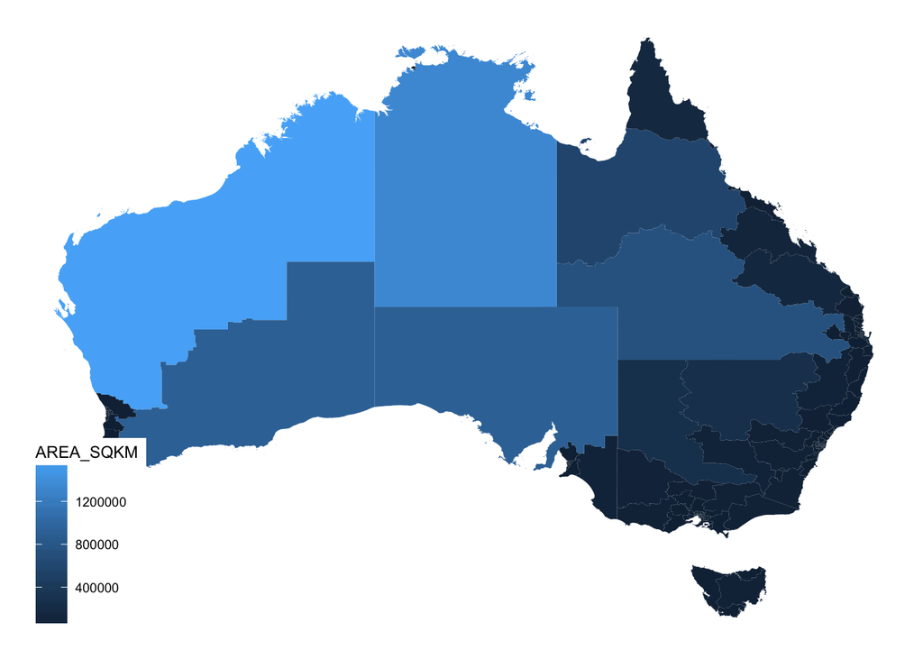

```r
library(ggplot2)
library(ggthemes)
ggplot(aes(map_id=id), data=nat_data) +
  geom_map(aes(fill=AREA_SQKM), map=nat_map) +
  expand_limits(x=nat_map$long, y=nat_map$lat) +
  theme_map()
```